# EX4-SNA

Motahhreh Nadimi

21/04/2020

## Exercise 1

** Built an arbitrary two-mode network and retrieve the associated one-mode networks, What do the diagonal and off-diagonal entries mean?**

```r
library(igraph)
library(statnet)
set.seed(123)
n1 <- 6
n2 <- 5
n <- n1 + n2
# define the probability of connection among nodes of different sets
p <- .5
# generate random bipartite graph.
g <- sample_bipartite(n1, n2, type="Gnp", p = p, directed=FALSE)
g
```

```
## IGRAPH 175fefd U--B 11 13 -- Bipartite Gnp random graph
## + attr: name (g/c), p (g/n), type (v/l)
## + edges from 175fefd:
##  [1] 2-- 7 6-- 7 1-- 8 2-- 8 3-- 8 3-- 9 1--10 2--10 3--10 4--10 6--10
## [12] 5--11 6--11
```

```r
# check the type attribute:
V(g)$type
```

```
##  [1] FALSE FALSE FALSE FALSE FALSE FALSE  TRUE  TRUE  TRUE  TRUE  TRUE
```

```r
AM <- get.incidence(g)
colnames(AM) <- c("M1","M2","M3","M4","M5")
row.names(AM) <- c("F1","F2","F3","F4","F5","F6")
b <- graph.incidence(AM)
AM
```

```
##    M1 M2 M3 M4 M5
## F1  0  1  0  1  0
## F2  1  1  0  1  0
## F3  0  1  1  1  0
## F4  0  0  0  1  0
## F5  0  0  0  0  1
## F6  1  0  0  1  1
```

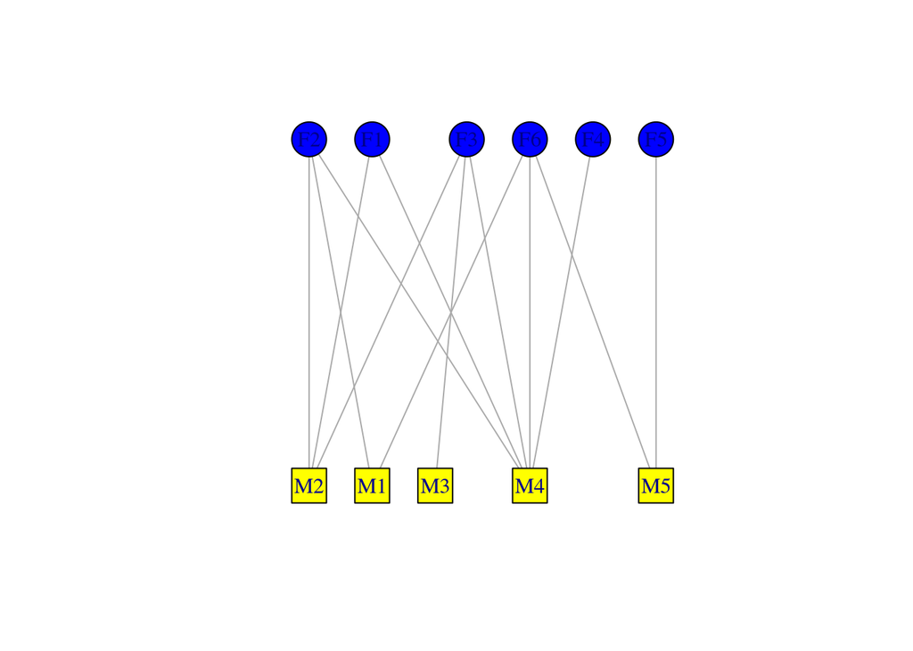

```r
# define color and shape mappings.
col <- c("blue", "yellow")
shape <- c("circle", "square")

plot(b,
     vertex.color = col[as.numeric(V(b)$type)+1],
     vertex.shape = shape[as.numeric(V(b)$type)+1],layout=layout.bipartite,
     vertex.size=20)
```

```r
  is_bipartite(g)
```

```
## [1] TRUE
```

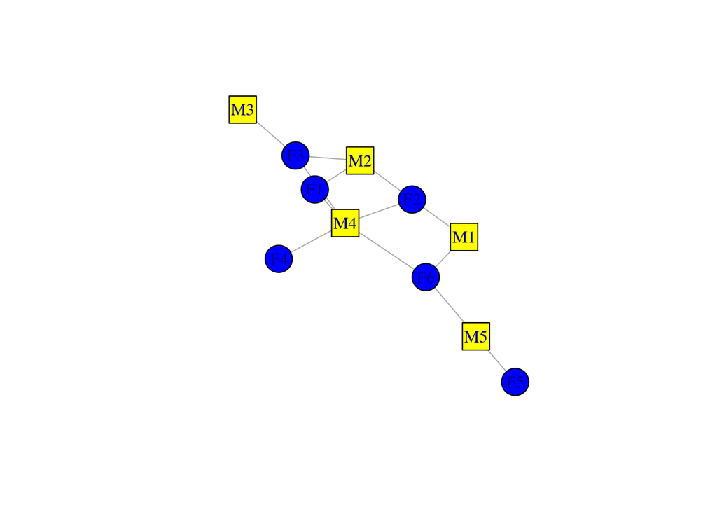

```r
#alternative plotting , I just remove layout
plot(b,
  vertex.color = col[as.numeric(V(b)$type)+1],
  vertex.shape = shape[as.numeric(V(b)$type)+1],
  vertex.size=20)
```

```r
is_bipartite(g)
```

```
## [1] TRUE
```

**we project two mode graph to one mode graph**

```r
g.pr <- bipartite.projection(b)

g.pr
```

```
## $proj1
## IGRAPH d8acbcf UNW- 6 11 --
## + attr: name (v/c), weight (e/n)
## + edges from d8acbcf (vertex names):
##  [1] F1--F2 F1--F3 F1--F4 F1--F6 F2--F6 F2--F3 F2--F4 F3--F4 F3--F6 F4--F6
## [11] F5--F6
##
## $proj2
## IGRAPH bad1c07 UNW- 5 7 --
## + attr: name (v/c), weight (e/n)
## + edges from bad1c07 (vertex names):
## [1] M1--M2 M1--M4 M1--M5 M2--M4 M2--M3 M3--M4 M4--M5
```

```r
g.side1 <-g.pr$proj1
g.side2 <- g.pr$proj2

get.adjacency(g.side1,sparse=FALSE,attr="weight")
```

```
##    F1 F2 F3 F4 F5 F6
## F1  0  2  2  1  0  1
## F2  2  0  2  1  0  2
## F3  2  2  0  1  0  1
## F4  1  1  1  0  0  1
## F5  0  0  0  0  0  1
## F6  1  2  1  1  1  0
```

```r
get.adjacency(g.side2,sparse=FALSE,attr="weight")
```

```
##    M1 M2 M3 M4 M5
## M1  0  1  0  2  1
## M2  1  0  1  3  0
## M3  0  1  0  1  0
## M4  2  3  1  0  1
## M5  1  0  0  1  0
```

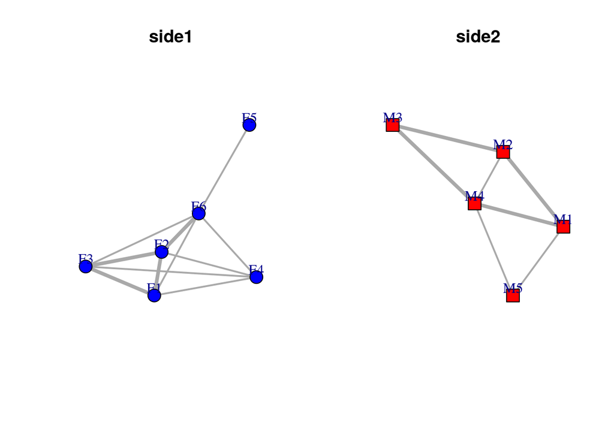

```r
#we plot each of the one mode network:
shapes <- c("circle","square")
colors <- c("blue","red")
op <- par(mfrow=c(1,2))
plot(g.side1,vertex.color="blue",
     vertex.shape="circle",main="side1",
     edge.width=E(g.side1)$weight*2,
     vertex.size=15,vertex.label.degree=-pi/2,
     vertex.label.dist=1.2,vertex.label.cex=1)
plot(g.side2,vertex.color="red",
     vertex.shape="square",main="side2",
     edge.width=E(g.side1)$weight*2,
     vertex.size=15,vertex.label.degree=-pi/2,
     vertex.label.dist=1.2,vertex.label.cex=1)
```

**What do the diagonal and off-diagonal entries mean? The adjacency matrix of each one-mode projection males are undirectly connected through thier shared friend. M1 and M4 are indirectly connected through thier 2 common female friend but M1 and M2 are indirectly connected via one female friend.**

## Exercise 2

**Use the Davis data (Davis.txt file from the first R Lab) and transform it in a hypergraph of an object of class network.**

**A hypergraph is just a graph G=(V,E) where V is the set of vertices (nodes) and E is a subset of the powerset of V. It is a data structure. So a common graph is just a hypergraph with rank 2. (i.e each set in E contains exactly two vertices). A directed hypergraph uses pairs (X,Y) as the edges where X and Y are sets.**

```r
h1<-read.table("/home/elham/Desktop/rrrrrrrrrrrrrrrrr/SNA/R LAB March 30th-20200417/Davis.txt",header = T, row.names = 1)
h1
```

```
##           E1 E2 E3 E4 E5 E6 E7 E8 E9 E10 E11 E12 E13 E14
## EVELYN     1  1  1  1  1  1  0  1  1   0   0   0   0   0
## LAURA      1  1  1  0  1  1  1  1  0   0   0   0   0   0
## THERESA    0  1  1  1  1  1  1  1  1   0   0   0   0   0
## BRENDA     1  0  1  1  1  1  1  1  0   0   0   0   0   0
## CHARLOTTE  0  0  1  1  1  0  1  0  0   0   0   0   0   0
## FRANCES    0  0  1  0  1  1  0  1  0   0   0   0   0   0
## ELEANOR    0  0  0  0  1  1  1  1  0   0   0   0   0   0
## PEARL      0  0  0  0  0  1  0  1  1   0   0   0   0   0
## RUTH       0  0  0  0  1  0  1  1  1   0   0   0   0   0
## VERNE      0  0  0  0  0  0  1  1  1   0   0   1   0   0
## MYRA       0  0  0  0  0  0  0  1  1   1   0   1   0   0
## KATHERINE  0  0  0  0  0  0  0  1  1   1   0   1   1   1
## SYLVIA     0  0  0  0  0  0  1  1  1   1   0   1   1   1
## NORA       0  0  0  0  0  1  1  0  1   1   1   1   1   1
## HELEN      0  0  0  0  0  0  1  1  0   1   1   1   0   0
## DOROTHY    0  0  0  0  0  0  0  1  1   0   0   0   0   0
## OLIVIA     0  0  0  0  0  0  0  0  1   0   1   0   0   0
## FLORA      0  0  0  0  0  0  0  0  1   0   1   0   0   0
```

```r
class(h1)
```

```
## [1] "data.frame"
```

```r
row.names(h1)
```

```
##  [1] "EVELYN"    "LAURA"     "THERESA"   "BRENDA"    "CHARLOTTE"
##  [6] "FRANCES"   "ELEANOR"   "PEARL"     "RUTH"      "VERNE"
## [11] "MYRA"      "KATHERINE" "SYLVIA"    "NORA"      "HELEN"
## [16] "DOROTHY"   "OLIVIA"    "FLORA"
```

```r
colnames(h1)
```

```
##  [1] "E1"  "E2"  "E3"  "E4"  "E5"  "E6"  "E7"  "E8"  "E9"  "E10" "E11"
## [12] "E12" "E13" "E14"
```

```r
f <- network(h1, matrix = "incidence", hyper = TRUE, directed = FALSE, loops = TRUE, multiple = TRUE)
f[,]
```

```
##    1 2 3 4 5 6 7 8 9 10 11 12 13 14 15 16 17 18
## 1  1 1 1 1 1 1 1 1 1  1  1  1  1  1  1  1  1  1
## 2  1 1 1 1 1 1 1 1 1  1  1  1  1  1  1  1  0  0
## 3  1 1 1 1 1 1 1 1 1  1  1  1  1  1  1  1  1  1
## 4  1 1 1 1 1 1 1 1 1  1  1  1  1  1  1  1  0  0
## 5  1 1 1 1 1 1 1 0 1  1  0  0  1  1  1  0  0  0
## 6  1 1 1 1 1 1 1 1 1  1  1  1  1  1  1  1  0  0
## 7  1 1 1 1 1 1 1 1 1  1  1  1  1  1  1  1  0  0
## 8  1 1 1 1 0 1 1 1 1  1  1  1  1  1  1  1  1  1
## 9  1 1 1 1 1 1 1 1 1  1  1  1  1  1  1  1  1  1
## 10 1 1 1 1 1 1 1 1 1  1  1  1  1  1  1  1  1  1
## 11 1 1 1 1 0 1 1 1 1  1  1  1  1  1  1  1  1  1
## 12 1 1 1 1 0 1 1 1 1  1  1  1  1  1  1  1  1  1
## 13 1 1 1 1 1 1 1 1 1  1  1  1  1  1  1  1  1  1
## 14 1 1 1 1 1 1 1 1 1  1  1  1  1  1  1  1  1  1
## 15 1 1 1 1 1 1 1 1 1  1  1  1  1  1  1  1  1  1
## 16 1 1 1 1 0 1 1 1 1  1  1  1  1  1  1  1  1  1
## 17 1 0 1 0 0 0 0 1 1  1  1  1  1  1  1  1  1  1
## 18 1 0 1 0 0 0 0 1 1  1  1  1  1  1  1  1  1  1
```

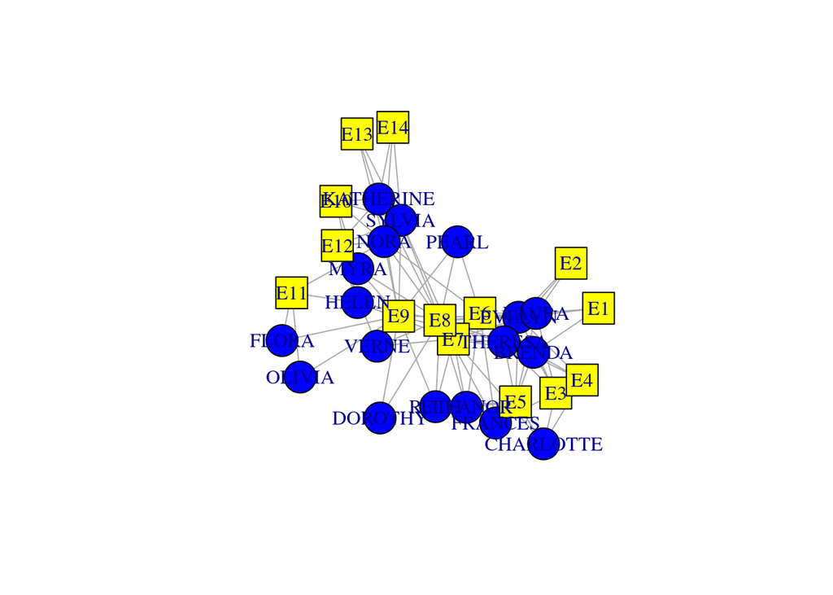

```r
#as.matrix(network(t(h1)),matrix.type = "incidence")
g <- igraph::graph_from_incidence_matrix(h1)
col <- c("blue", "yellow")
shape <- c("circle", "square")

plot(g,
     vertex.color = col[as.numeric(V(g)$type)+1],
     vertex.shape = shape[as.numeric(V(g)$type)+1],
     vertex.size=20)
```

```r
is_bipartite(g)
```

```
## [1] TRUE
```

```r
#plot(g)
```

## Exercise 3

**By considering the data(“faux.magnolia.high”) in statnet and using the manipulation functions in the networkScript.R:**

**a. count how many isolates there are**

**b. add all possible edges among nodes with Race=“Black” and plot the resulting network**

**c. delete all nodes with Race=“natAm” and plot the resulting network**

**d. delete all neighborhood edges of the most connected node**

**e. creat te the subgraphs of Females and Males**

```r
data(faux.magnolia.high)
v<- faux.magnolia.high
v
```

```
##  Network attributes:
##   vertices = 1461
##   directed = FALSE
##   hyper = FALSE
##   loops = FALSE
##   multiple = FALSE
##   bipartite = FALSE
##   total edges= 974
##     missing edges= 0
##     non-missing edges= 974
##
##  Vertex attribute names:
##     Grade Race Sex vertex.names
##
##  Edge attribute names not shown
```

```r
class(v)
```

```
## [1] "network"
```

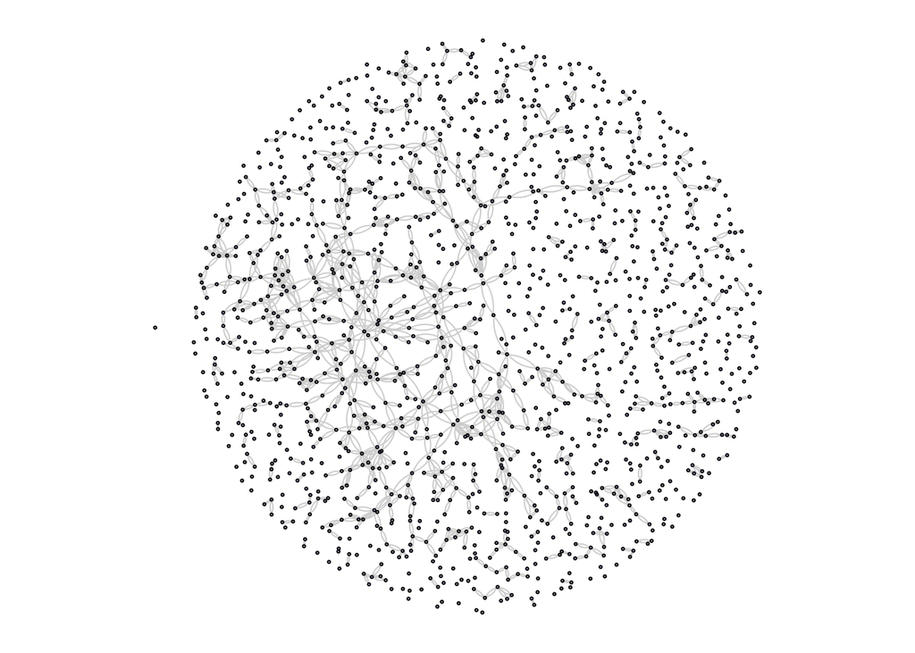

```r
#summary(faux.magnolia.high)

#get.node.attr(faux.magnolia.high,'Race')

par(mar=c(0,0,0,0))
gplot(faux.magnolia.high,gmode="graph",vertex.cex=0.6,
      vertex.col=rgb(0,0,139,alpha=80,
                     maxColorValue=255),
      edge.col="grey80",edge.lwd=0.02,
      thresh=0.01,jitter=TRUE, usecurve=TRUE)
```

**a. count how many isolates there are:from this output, we can see the # of isolated out is 524**

```r
table(component.dist(v)$csize)
```

```
##
##   1   2   3   4   5   6   7   8   9  11  12  19  23 439
## 524  64  29  11  12   4   7   4   1   1   1   1   1   1
```

**extra work.we can plot data regarding attribute RACE**

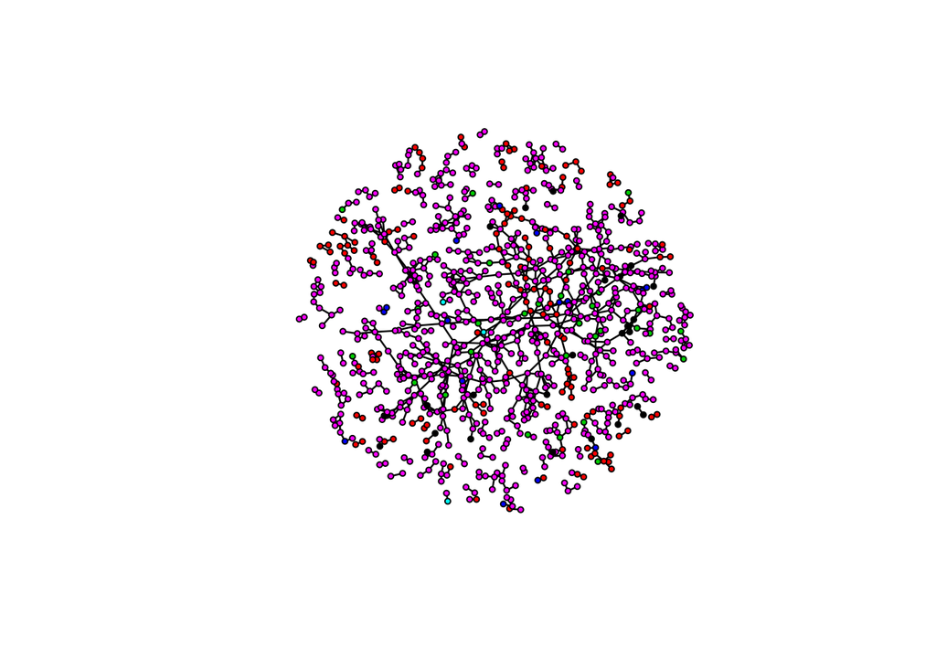

```r
plot(v, displayisolates = FALSE, vertex.col = "Race", vertex.cex = 0.7)
```

**b. add all possible edges among nodes with Race=“Black” and plot the resulting networksummary(faux.magnolia.high)**

```r
summary(v ~ edges) # Look at the $g(y)$ statistic for this model
```

```
## edges
##   974
```

```r
list.vertex.attributes(v) # List all vertex attributes
```

```
## [1] "Grade"        "na"           "Race"         "Sex"
## [5] "vertex.names"
```

```r
gr <- v %v% "Race"
table(gr)
```

```
## gr
## Asian Black  Hisp NatAm Other White
##    48   261    68    24     7  1053
```

```r
l <- get.inducedSubgraph(v,
                           which(v %v% "Race" == "Black"))
l
```

```
##  Network attributes:
##   vertices = 261
##   directed = FALSE
##   hyper = FALSE
##   loops = FALSE
##   multiple = FALSE
##   bipartite = FALSE
##   total edges= 85
##     missing edges= 0
##     non-missing edges= 85
##
##  Vertex attribute names:
##     Grade Race Sex vertex.names
##
##  Edge attribute names not shown
```

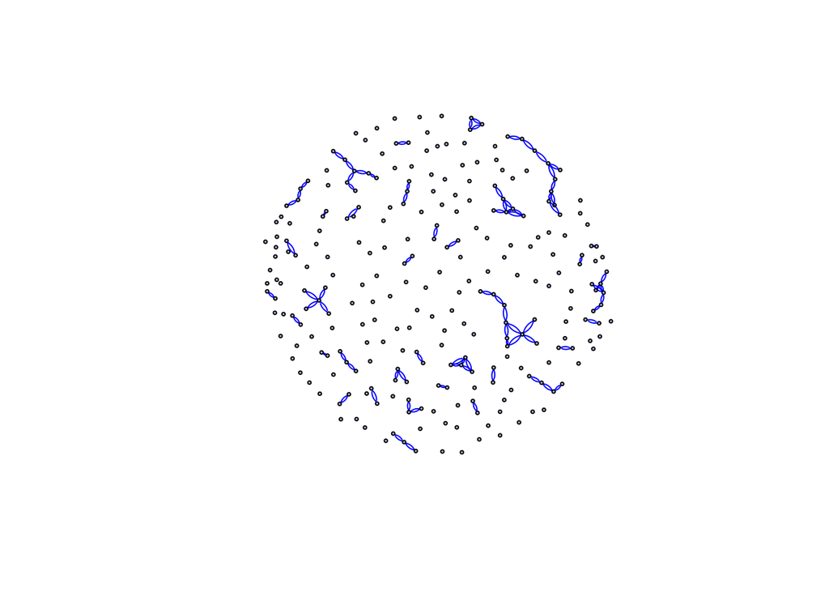

```r
gplot(l,gmode="graph",vertex.cex=0.6,
      vertex.col=rgb(0,0,139,alpha=80,
                     maxColorValue=255),
      edge.col="blue",edge.lwd=0.02,
      thresh=0.01,jitter=TRUE, usecurve=TRUE)
```

**c. delete all nodes with Race=“natAm” and plot the resulting networkdelete.vertices() modifies the network in place!**

```r
list.vertex.attributes(v)
```

```
## [1] "Grade"        "na"           "Race"         "Sex"
## [5] "vertex.names"
```

```r
del <- v %v% "Race"
n2 <- v %s% which(del== "NatAm")
n2
```

```
##  Network attributes:
##   vertices = 24
##   directed = FALSE
##   hyper = FALSE
##   loops = FALSE
##   multiple = FALSE
##   bipartite = FALSE
##   total edges= 3
##     missing edges= 0
##     non-missing edges= 3
##
##  Vertex attribute names:
##     Grade Race Sex vertex.names
##
##  Edge attribute names not shown
```

```r
as.sociomatrix(n2)
```

```
##      72 114 301 320 390 399 474 561 608 730 755 813 890 896 906 954 1013
## 72    0   0   1   0   0   0   0   0   0   0   0   0   0   0   0   0    0
## 114   0   0   0   0   0   0   0   0   0   0   0   0   1   0   0   0    0
## 301   1   0   0   0   0   0   0   0   0   0   0   0   0   0   0   0    0
## 320   0   0   0   0   0   0   0   0   0   0   0   0   0   0   0   0    0
## 390   0   0   0   0   0   0   0   0   0   0   0   0   0   0   0   0    0
## 399   0   0   0   0   0   0   0   0   0   0   0   0   0   0   0   0    0
## 474   0   0   0   0   0   0   0   0   0   0   0   0   0   0   0   0    0
## 561   0   0   0   0   0   0   0   0   0   0   0   0   0   0   0   0    0
## 608   0   0   0   0   0   0   0   0   0   0   0   0   0   0   0   0    1
## 730   0   0   0   0   0   0   0   0   0   0   0   0   0   0   0   0    0
## 755   0   0   0   0   0   0   0   0   0   0   0   0   0   0   0   0    0
## 813   0   0   0   0   0   0   0   0   0   0   0   0   0   0   0   0    0
## 890   0   1   0   0   0   0   0   0   0   0   0   0   0   0   0   0    0
## 896   0   0   0   0   0   0   0   0   0   0   0   0   0   0   0   0    0
```

[output cut: 35 more lines]

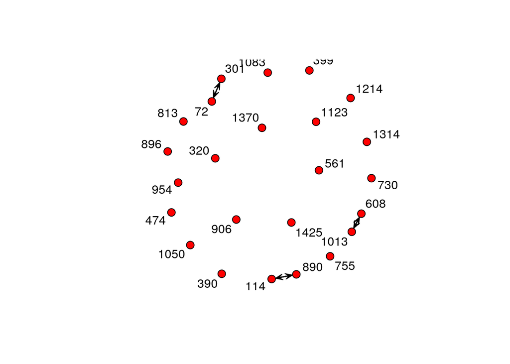

```r
gplot(n2,displaylabels=TRUE)
```

```r
#now we should delete n2
delete.vertices(v, vid = which(v %v% "Race"=="NatAm"))
gr <- v %v% "Race"
table(gr)
```

```
## gr
## Asian Black  Hisp Other White
##    48   261    68     7  1053
```

**delete all neighborhood edges of the most connected node**

```r
fmh <- faux.magnolia.high
fmh
```

```
##  Network attributes:
##   vertices = 1461
##   directed = FALSE
##   hyper = FALSE
##   loops = FALSE
##   multiple = FALSE
##   bipartite = FALSE
##   total edges= 974
##     missing edges= 0
##     non-missing edges= 974
##
##  Vertex attribute names:
##     Grade Race Sex vertex.names
##
##  Edge attribute names not shown
```

```r
degreedist(faux.magnolia.high)
```

```
## degree0 degree1 degree2 degree3 degree4 degree5 degree6 degree7 degree8
##     524     403     271     128      85      30      13       5       2
```

```r
Degree <- degree(fmh)     #Computing the  of each node
table(Degree)
```

```
## Degree
##   0   2   4   6   8  10  12  14  16
## 524 403 271 128  85  30  13   5   2
```

```r
#Degree
which(Degree == 16)
```

```
## [1] 765 991
```

```r
#765
#991
fmh2 = delete.edges (fmh, get.edgeIDs(fmh,756, neighborhood = "in"))
fmh2
```

```
##  Network attributes:
##   vertices = 1461
##   directed = FALSE
##   hyper = FALSE
##   loops = FALSE
##   multiple = FALSE
##   bipartite = FALSE
##   total edges= 969
##     missing edges= 0
##     non-missing edges= 969
##
##  Vertex attribute names:
##     Grade Race Sex vertex.names
##
##  Edge attribute names not shown
```

```r
fmh3 = delete.edges (fmh2, get.edgeIDs(fmh2,991, neighborhood = "in"))
fmh3
```

```
##  Network attributes:
##   vertices = 1461
##   directed = FALSE
##   hyper = FALSE
##   loops = FALSE
##   multiple = FALSE
##   bipartite = FALSE
##   total edges= 961
##     missing edges= 0
##     non-missing edges= 961
##
##  Vertex attribute names:
##     Grade Race Sex vertex.names
##
##  Edge attribute names not shown
```

**create the subgraphs of Females and Males**

```r
fmh <- faux.magnolia.high
fmh
```

```
##  Network attributes:
##   vertices = 1461
##   directed = FALSE
##   hyper = FALSE
##   loops = FALSE
##   multiple = FALSE
##   bipartite = FALSE
##   total edges= 974
##     missing edges= 0
##     non-missing edges= 974
##
##  Vertex attribute names:
##     Grade Race Sex vertex.names
##
##  Edge attribute names not shown
```

```r
#compare degree distributions by sex:
summary(fmh ~ degree(0:8, "Sex"))
```

```
## deg0.SexF deg1.SexF deg2.SexF deg3.SexF deg4.SexF deg5.SexF deg6.SexF
##       226       226       160        80        44        18         7
## deg7.SexF deg8.SexF deg0.SexM deg1.SexM deg2.SexM deg3.SexM deg4.SexM
##         5         2       298       177       111        48        41
## deg5.SexM deg6.SexM deg7.SexM deg8.SexM
##        12         6         0         0
```

```r
list.vertex.attributes(fmh)
```

```
## [1] "Grade"        "na"           "Race"         "Sex"
## [5] "vertex.names"
```

```r
#t <- fmh %v% "Sex"
#Subgraoh of female
n1F <- get.inducedSubgraph(fmh, which(fmh %v% "Sex" == "M" ))
n1F
```

```
##  Network attributes:
##   vertices = 693
##   directed = FALSE
##   hyper = FALSE
##   loops = FALSE
##   multiple = FALSE
##   bipartite = FALSE
##   total edges= 259
##     missing edges= 0
##     non-missing edges= 259
##
##  Vertex attribute names:
##     Grade Race Sex vertex.names
##
##  Edge attribute names not shown
```

```r
#subgraph of male.
n2F <- get.inducedSubgraph(fmh, which(fmh %v% "Sex" == "F" ))
n2F
```

```
##  Network attributes:
##   vertices = 768
##   directed = FALSE
##   hyper = FALSE
##   loops = FALSE
##   multiple = FALSE
##   bipartite = FALSE
##   total edges= 430
##     missing edges= 0
##     non-missing edges= 430
##
##  Vertex attribute names:
##     Grade Race Sex vertex.names
##
##  Edge attribute names not shown
```

**THANK YOU**